# Relación entre Alzheimer y Calidad del Aire y Zonas Verdes

Manuel Sánchez Paredes y Santiago Herrero Ruipérez

Universidad de Burgos, Ingeniería de la Salud

2 de Diciembre 2024

### [Repositorio](https://github.com/msp1030/SeminarioFuentes)

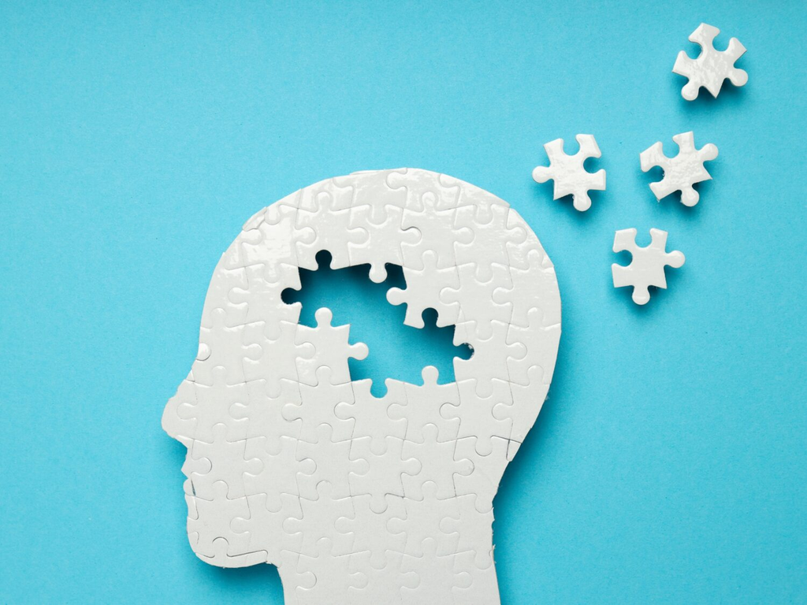

# 1. Introducción

El Alzheimer es una enfermedad neurodegenerativa de la que no se conoce con certeza sus orígenes y causas. Este trabajo busca explorar la posible relación entre factores ambientales como las zonas verdes o la calidad del aire con esta enfermdedad.

# 2. Objetivo General

El objetivo general de este trabajo es analizar si la baja calidad del aire y la escasez de zonas verdes en el entorno influye en la presencia de Alzheimer.

# 3 Carga de Datos

Los datos respecto al [Alzheimer](https://www.ine.es/jaxi/Datos.htm?tpx=51464) y a las [zonas verdes](https://www.ine.es/jaxi/Datos.htm?path=/t00/ICV/dim8/&file=82101.px#_tabs-tabla) se han obtenido del Instututo Nacional de Estadística (INE), mientras que los datos de la calidad del aire se han obtenido mediante el paquete `airqualiltyES` del proyecto [ROpenSpain](https://ropenspain.github.io/airqualityES/).

## 3.1 Carga de Zonas Verdes

```r
zonas_verdes <- read.px("INPUT/DATA/zonas_verdes.px")$DATA
zonas_verdes_df <- zonas_verdes$value
zonas_verdes_df<-zonas_verdes_df[-c(1,2,3,4,5), ]
wide_zonas_verdes<-
  zonas_verdes_df%>%
  rename(Comunidades = Comunidades.y.Ciudades.Autónomas) %>%
  pivot_wider(names_from = "Nivel.de.satisfacción", values_from = "value") %>%
  rename(Valoracion_media = "Valoración media")
wide_zonas_verdes<-wide_zonas_verdes[,-c(2:5)]
```

|  | Comunidades | Valoracion_media |
| --- | --- | --- |
| 1 | 01 Andalucía | 6.3 |
| 2 | 02 Aragón | 6.7 |
| 3 | 03 Asturias, Principado de | 7.6 |
| 4 | 04 Balears, Illes | 6.7 |
| 5 | 05 Canarias | 5.9 |
| 6 | 06 Cantabria | 7.1 |
| 7 | 07 Castilla y León | 7.1 |
| 8 | 08 Castilla - La Mancha | 6.9 |
| 9 | 09 Cataluña | 6.9 |
| 10 | 10 Comunitat Valenciana | 6.7 |

[output cut: 9 more lines]

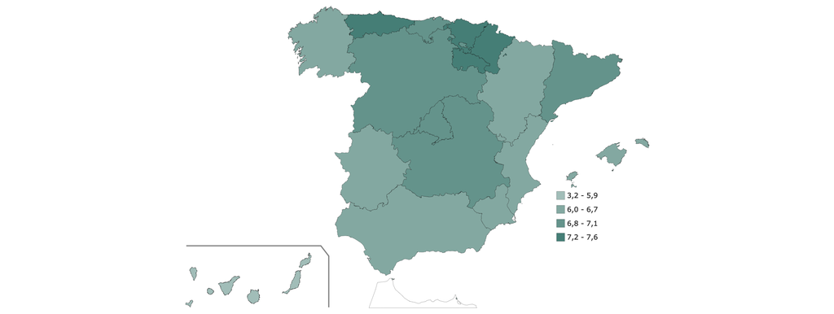

## 3.2 Carga de Alzheimer

Los datos de Alzheimer, al igual que los datos de zonas verdes se encuentran en formato PC-AXIS, por lo que se emplea el paquete `pxR` para leer los datos. Se modifica la tabla para eliminar las columnas innecesarias.

```r
alzheimer <- read.px("INPUT/DATA/alzheimer_total.px")$DATA
alzheimer_df<-alzheimer$value
alzheimer_df<-alzheimer_df[,-c(1,2)] %>%
  rename(porcentaje_alzheimer = value, Comunidades = Comunidades.y.Ciudades.Autónomas)
```

|  | Comunidades | porcentaje_alzheimer |
| --- | --- | --- |
| 1 | Total Nacional | 5.55 |
| 2 | 01 Andalucía | 5.55 |
| 3 | 02 Aragón | 4.72 |
| 4 | 03 Asturias, Principado de | 5.7 |
| 5 | 04 Balears, Illes | 6.13 |
| 6 | 05 Canarias | 6.3 |
| 7 | 06 Cantabria | 4.62 |
| 8 | 07 Castilla y León | 4.88 |
| 9 | 08 Castilla - La Mancha | 6 |
| 10 | 09 Cataluña | 5.67 |

[output cut: 10 more lines]

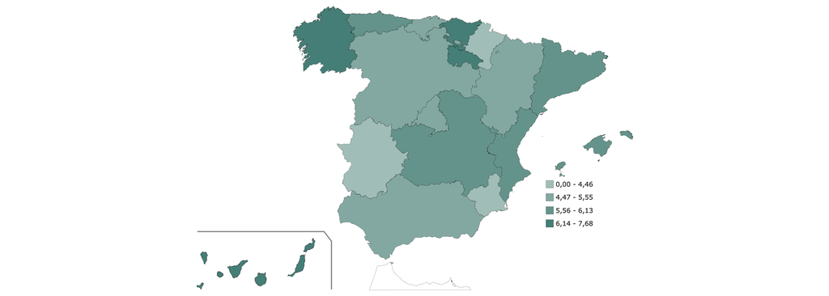

## 3.3 Carga de Calidad del Aire

La tabla con los datos de la Calidad del Aire se encuentra cargada por el paquete `airqES`.

La primera modificación de los datos es filtrar por el año de interés, en este caso 2018, y hacer la media de los dias de cada mes para cada estación.

```r
calidad_aire <- airqES %>%
  filter(year == 2018) %>%
  mutate(media_mensual = apply(.[, c(8:38)], 1, mean, na.rm = TRUE))%>%
  select(month, province, station_id, pollutant, media_mensual)
```

Luego, se establecen los meses y provincias por su nombre en lugar de números.

```r
str(meses)
```

```
##  chr [1:12] "Enero" "Febrero" "Marzo" "Abril" "Mayo" "Junio" "Julio" ...
```

```r
str(provincias)
```

```
##  chr [1:50] "Alava" "Albacete" "Alicante" "Almeria" "Avila" "Badajoz" ...
```

```r
calidad_aire$month<-meses[calidad_aire$month]
calidad_aire$province<-provincias[calidad_aire$province]
```

A continuación, se pivota para establecer los meses como atributos, y se hace la media de sus valores para obtener la media anual de cada estación.

```r
wide_calidad_aire<-
  calidad_aire%>%
  pivot_wider(names_from = "month", values_from = "media_mensual")

wide_calidad_aire<-
  wide_calidad_aire%>%
  mutate(media_anual = apply(.[, c(4:15)], 1, mean, na.rm = TRUE)) %>% select(province:pollutant, media_anual)
```

Se pasan las medidas de los contaminantes a porcentajes del valor límite.

```r
wide_calidad_aire <-mutate(.data = wide_calidad_aire,
  porcentaje = case_when(
    !is.na(media_anual) & pollutant == "PM10" ~ (media_anual / 40) * 100,
    !is.na(media_anual) & pollutant == "PM2.5" ~ (media_anual / 25) * 100,
    !is.na(media_anual) & pollutant == "Pb" ~ (media_anual / 0.5) * 100,
    !is.na(media_anual) & pollutant == "As" ~ (media_anual / 6) * 100,
    !is.na(media_anual) & pollutant == "Cd" ~ (media_anual / 5) * 100,
    !is.na(media_anual) & pollutant == "Ni" ~ (media_anual / 20) * 100,
    !is.na(media_anual) & pollutant == "B(a)P" ~ (media_anual / 1) * 100
  )
) %>% select(province:pollutant, porcentaje)
```

Se hace la media de los valores de cada contaminante dentro de una misma provincia, y luego se juntan los valores de los contaminantes.

```r
wide_calidad_aire <- group_by(.data = wide_calidad_aire, province, pollutant) %>%
  dplyr::summarise(media_porcentaje = mean(porcentaje, na.rm = TRUE)) %>%
  ungroup()%>%
  group_by(province) %>%
  dplyr::summarise(airQ = mean(media_porcentaje, na.rm = TRUE)) %>%
  ungroup()
```

Finalmente, se agrupan los valores en cada comunidad autónoma empleando un dataframe con las provincias y las comunidades.

```r
provincias_comunidades <- data.frame(
  province = provincias,
  comunidad_autonoma = Comunidades)
```

```r
calidad_aire_comunidades<-left_join(wide_calidad_aire,provincias_comunidades)
airQ<- calidad_aire_comunidades%>%
  rename(Comunidades = comunidad_autonoma) %>%
  group_by(Comunidades)%>%
  dplyr::summarise(media_airQ=mean(airQ))
airQ$media_airQ <- 100- airQ$media_airQ
```

|  | Comunidades | media_airQ |
| --- | --- | --- |
| 1 | 01 Andalucía | 71.38835924803719 |
| 2 | 02 Aragón | 76.05325628882255 |
| 3 | 03 Asturias, Principado de | 64.54916290121494 |
| 4 | 04 Balears, Illes | 75.46760979577448 |
| 5 | 05 Canarias | 66.62224977476355 |
| 6 | 06 Cantabria | 80.13308392265891 |
| 7 | 07 Castilla y León | 76.962527685108 |
| 8 | 08 Castilla - La Mancha | 71.89304639837002 |
| 9 | 09 Cataluña | 79.25210875304008 |
| 10 | 10 Comunitat Valenciana | 68.10924730434726 |

[output cut: 7 more lines]

En el siguiente gráfico se muestra la calidad del aire en cada comunidad autónoma.

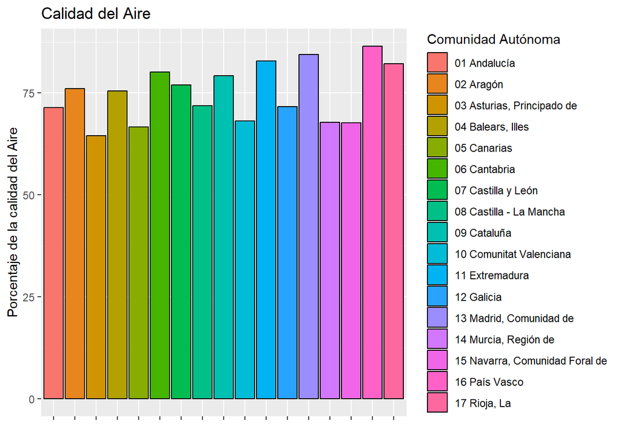

```r
grafico0 <- ggplot(data = airQ, aes(x = Comunidades, y = media_airQ)) +
  geom_col(aes(fill = Comunidades), colour = "black") +
  xlab("") +
  ylab("Porcentaje de la calidad del Aire") +
  theme(axis.text.x = element_blank()) +
  labs(fill = "Comunidad Autónoma", title = "Calidad del Aire")
```

# 4. Objetivos Específicos

## 4.1 Relación entre Alzheimer y Zonas Verdes

Se espera que a una mejor valoración de zonas verdes, el Alzheimer disminuya.

```r
alzheimer_zonas_verdes<-left_join(x = alzheimer_df, y = wide_zonas_verdes, by = c("Comunidades"))

alzheimer_zonas_verdes<-alzheimer_zonas_verdes[-c(1, 19, 20),]
```

|  | Comunidades | porcentaje_alzheimer | Valoracion_media |
| --- | --- | --- | --- |
| 2 | 01 Andalucía | 5.55 | 6.3 |
| 3 | 02 Aragón | 4.72 | 6.7 |
| 4 | 03 Asturias, Principado de | 5.7 | 7.6 |
| 5 | 04 Balears, Illes | 6.13 | 6.7 |
| 6 | 05 Canarias | 6.3 | 5.9 |
| 7 | 06 Cantabria | 4.62 | 7.1 |
| 8 | 07 Castilla y León | 4.88 | 7.1 |
| 9 | 08 Castilla - La Mancha | 6 | 6.9 |
| 10 | 09 Cataluña | 5.67 | 6.9 |
| 11 | 10 Comunitat Valenciana | 5.62 | 6.7 |

[output cut: 7 more lines]

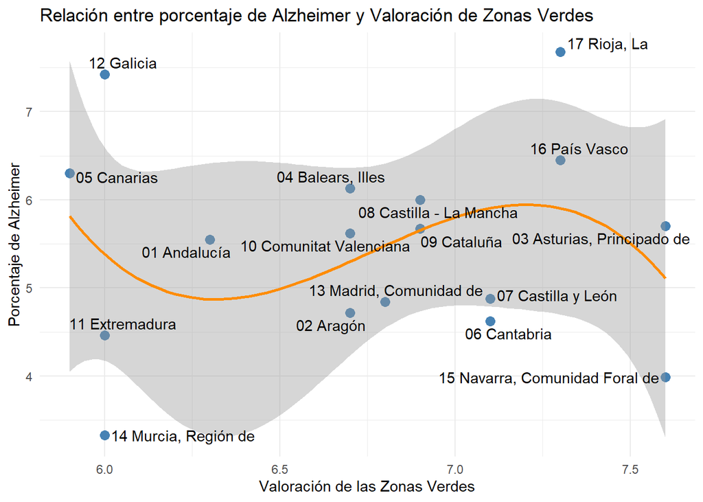

```r
grafico1 <- ggplot(alzheimer_zonas_verdes, aes(x = Valoracion_media, y = porcentaje_alzheimer)) +
  geom_point(color = "steelblue", size = 3) +
  geom_smooth(method = "lm", formula = y~poly(x, 3), color = "darkorange", se = TRUE) +
  geom_text_repel(aes(label = Comunidades)) +
  labs(title = "Relación entre porcentaje de Alzheimer y Valoración de Zonas Verdes",
       x = "Valoración de las Zonas Verdes",
       y = "Porcentaje de Alzheimer") +
  theme_minimal()
```

En la gráfica se puede observar que no hay una fuerte relación entre la percepción de la población de las zonas verdes y el porcentaje de Alzheimer en dicha población. Hay valores de Alzheimer muy dispares para valoraciones similares de Zonas Verdes.

## 4.2 Relación entre Calidad del Aire y Alzheimer

Se espera que los resultados indiquen una relación entre ambas variables, con peor calidad del aire una mayor afectación de Alzheimer a la población.

```r
airQ_alzheimer <- left_join(airQ, alzheimer_df)
```

|  | Comunidades | media_airQ | porcentaje_alzheimer |
| --- | --- | --- | --- |
| 1 | 01 Andalucía | 71.38835924803719 | 5.55 |
| 2 | 02 Aragón | 76.05325628882255 | 4.72 |
| 3 | 03 Asturias, Principado de | 64.54916290121494 | 5.7 |
| 4 | 04 Balears, Illes | 75.46760979577448 | 6.13 |
| 5 | 05 Canarias | 66.62224977476355 | 6.3 |
| 6 | 06 Cantabria | 80.13308392265891 | 4.62 |
| 7 | 07 Castilla y León | 76.962527685108 | 4.88 |
| 8 | 08 Castilla - La Mancha | 71.89304639837002 | 6 |
| 9 | 09 Cataluña | 79.25210875304008 | 5.67 |
| 10 | 10 Comunitat Valenciana | 68.10924730434726 | 5.62 |

[output cut: 7 more lines]

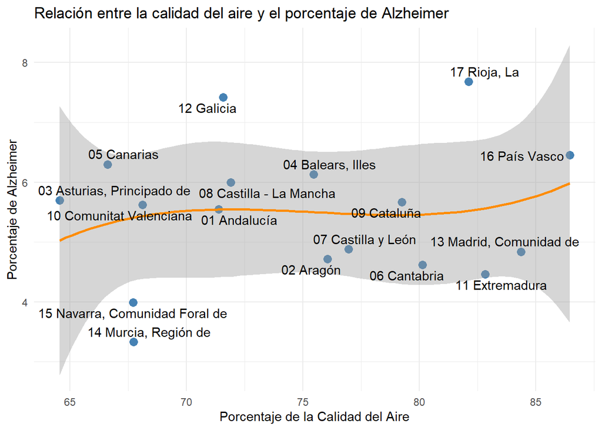

```r
grafico2 <- ggplot(airQ_alzheimer, aes(x = media_airQ, y = porcentaje_alzheimer)) +
  geom_point(color = "steelblue", size = 3) +
  geom_smooth(method = "lm", formula = y~poly(x, 3), color = "darkorange", se = TRUE) +
  geom_text_repel(aes(label = Comunidades)) +
  labs(title = "Relación entre la calidad del aire y el porcentaje de Alzheimer",
       x = "Porcentaje de la Calidad del Aire",
       y = "Porcentaje de Alzheimer") +
  theme_minimal()
```

## 4.3 Relación entre Calidad del Aire y Zonas Verdes

Se espera que la gráfica nos muestre una relación positiva entre ambas variables.

```r
airQ_Zonas_Verdes <- left_join(airQ, wide_zonas_verdes)
```

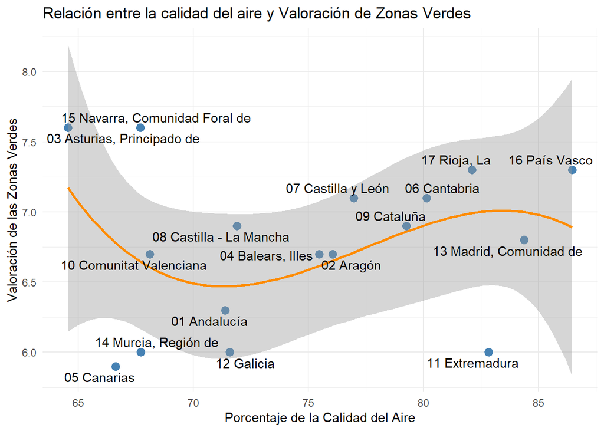

```r
grafico3 <- ggplot(airQ_Zonas_Verdes, aes(x = media_airQ, y = Valoracion_media)) +
  geom_point(color = "steelblue", size = 3) +
  geom_smooth(method = "lm", formula = y~poly(x, 3), color = "darkorange", se = TRUE) +
  geom_text_repel(aes(label = Comunidades)) +
  labs(title = "Relación entre la calidad del aire y Valoración de Zonas Verdes",
       x = "Porcentaje de la Calidad del Aire",
       y = "Valoración de las Zonas Verdes") +
  theme_minimal()
```

En esta gráfica se puede observar que hay una relación directa entre ambas variables si exceptuamos los extremos. Se mantiene de forma general, que a mejor calidad del aire, la percepción de las zonas verdes por la población mejora.

# 5. Conclusiones

Las zonas verdes se valoran mejor cuanto mejor sea la calidad del aire de cada zona, aunque hay ciertos casos en los que no se cumple. Esto se puede deber a las diferencias entre las zonas verdes de diferentes regiones, ya que la calidad del aire es solo uno de los factores que pueden afectar.

En cuanto a la relación entre la percepción de las zonas verdes y el Alzheimer, los valores son muy dispersos, y no indican una fuerte relación entre ambas variables.

# 6. Referencias

- INE - Instituto Nacional de Estadística. (s. f.-a). INE. Instituto Nacional de Estadística. INE. https://www.ine.es/
- Air Quality Measurements in Spain from 2011 to 2018. (s. f.). https://ropenspain.github.io/airqualityES/
- Ministerio de Agricultura,Pesca y Alimentación. (s. f.). https://www.mapa.gob.es/es/
- ¿Qué es el Alzheimer? (s. f.-b). Alzheimer’s Disease And Dementia. https://www.alz.org/alzheimer-demencia/que-es-la-enfermedad-de-alzheimer